# Weighted Quantile Sum Regression

Bradley Bowen

05 April, 2023

Assume we are interested in exploring the relationship between the chemical exposures and the outcome (BMI for example). These chemical exposures are usually highly correlated with each other (known as multicollinearity phenomenon in regression). Multicollinearity among the exposures violates the independence model assumption of multivariate linear regression, distorting statistical inference. To eliminate the issue of multicollinearity, we can consider summarizing these highly correlated chemical mixtures when putting them into a regression model. The idea of summary motivates the weighted quantile sum regression.

Unlike ordinary multivariate regression, the Weighted Quantile Sum Regression (WQS) model uses quantiles of chemical exposures and weighs them based on their individual impacts on the overall outcome. The exposure that has a strong impact on the mixture are assigned a greater weight while others that are not as critical are given a lower weight. The weighted sum of quantiles of chemical exposures is then treated as a predictor and regress on the response variable. We utilize the r package `gWQS` to illustrate model fitting, prediction, and evaluation.

## Libraries

In order to investigate relationships between chemical exposures using the `gWQS` package, there are several packages in R that must be loaded. Similar to previous tutorials where packages were introduced, we will be using `tidyverse` and `tidymodels` for data wrangling and model building, but we will also use `ggcorrplot` for data visualization.

In order to use the new packages in this tutorial, they must first be installed in R by running the following lines of code `install.packages("ggcorrplot")` and `install.packages("gWQS")`in the console.

> Additional installations may be required for mac users!

```r
library(gWQS)
library(tidyverse)
library(tidymodels)
library(ggcorrplot)
```

> In this tutorial, we use the new base R pipe operator “|>” which is equivalent to “%>%”

## Exploratory Data Analysis

As discussed early, we want to apply Weighted Quantile Sums to a real world issue. This example uses the `NHANES` dataset to focus on specific chemical exposures: Phalates and Phytoestrogens. Both of these exposures can be detected in urine samples and we want to estimate their respective impact on the outcome, body mass index. In order to predict body mass index with urine samples, we first need to reintroduce the `NHANES` dataset for use in this example.

The NHANES dataset can be loaded into R:

```r
load(file='nhanes1518.rda')
head(nhanes1518)
```

```
## # A tibble: 6 × 52
##    SEQN WTINT2YR WTMEC…¹ RIDST…² RIAGE…³ RIDAG…⁴ INDFM…⁵ RIDRE…⁶ DMDED…⁷ DMDED…⁸
##   <int>    <dbl>   <dbl>   <int>   <int>   <int>   <dbl>   <int>   <int>   <int>
## 1 83732  134671. 135630.       2       1      62    4.39       3       5      NA
## 2 83733   24329.  25282.       2       1      53    1.32       3       3      NA
## 3 83734   12400.  12576.       2       1      78    1.51       3       3      NA
## 4 83735  102718. 102079.       2       2      56    5          3       5      NA
## 5 83736   17628.  18235.       2       2      42    1.23       4       4      NA
## 6 83737   11252.  10879.       2       2      72    2.82       1       2      NA
## # … with 42 more variables: INDHHIN2 <int>, BMXBMI <dbl>, BMXWAIST <dbl>,
## #   BMXWT <dbl>, BMXHT <dbl>, URXUCR <dbl>, WTSB2YR <dbl>, URXCNP <dbl>,
## #   URDCNPLC <int>, URXCOP <dbl>, URDCOPLC <int>, URXECP <dbl>, URDECPLC <int>,
## #   URXHIBP <dbl>, URDHIBLC <int>, URXMBP <dbl>, URDMBPLC <int>, URXMC1 <dbl>,
## #   URDMC1LC <int>, URXMCOH <dbl>, URDMCOLC <int>, URXMEP <dbl>,
## #   URDMEPLC <int>, URXMHBP <dbl>, URDMHBLC <int>, URXMHH <dbl>,
## #   URDMHHLC <int>, URXMHNC <dbl>, URDMCHLC <int>, URXMHP <dbl>, …
```

Once the data is loaded, we can proceed to understand how our chemical exposures (detected in urine samples) impact the body mass index of participants.

```r
nhanes <- nhanes1518 |>
    filter(RIDAGEYR >= 18)|>
    mutate(BMXBMI = log(BMXBMI))|>
    select(BMXBMI, URXMHBP, URXMOH, URXMHP, URXMHH, URXMCOH, URXMHNC, URXMHH, URXECP, URXHIBP, URXMIB)

nhanes <- drop_na(nhanes)

nhanes
```

```
## # A tibble: 3,523 × 10
##    BMXBMI URXMHBP URXMOH URXMHP URXMHH URXMCOH URXMHNC URXECP URXHIBP URXMIB
##     <dbl>   <dbl>  <dbl>  <dbl>  <dbl>   <dbl>   <dbl>  <dbl>   <dbl>  <dbl>
##  1   3.01    5.3     7.8   2       8.7    0.7     1.2    14.1    27.4   73.7
##  2   3.18    0.5     8.6   3.1    11.9    0.35    0.28   16.7     1.5    4.4
##  3   3.78    1.1     8.4   0.57   16.4    0.6     0.28   25.8     6.3   32.7
##  4   3.64    1.5     7.8   1.2    14.4    0.6     1.1    19.7     4.7    8.8
##  5   3.27    0.5     1.7   0.57    2.7    0.6     0.9     3.9     2      7.1
##  6   3.22    1.9    15.4   8.2    27.6    0.35    0.5    26.1     6.1   13.4
##  7   3.13    0.28    6     5.1     9.5   14.2    72.2    14.1     3.7   17
##  8   3.53    1.8     1.9   2.1     2.7    0.35    0.4     4       4.9   14.7
##  9   3.43    1.5     5     2.6     6.2    0.35    0.28    9.4     1.4    3.7
## 10   3.53    0.28    2.6   0.57    5.1    0.9     0.8     5.9     3.2   12.8
## # … with 3,513 more rows
```

To confirm the normality of the variable BMI, we can create a histogram to view the shape of the observations:

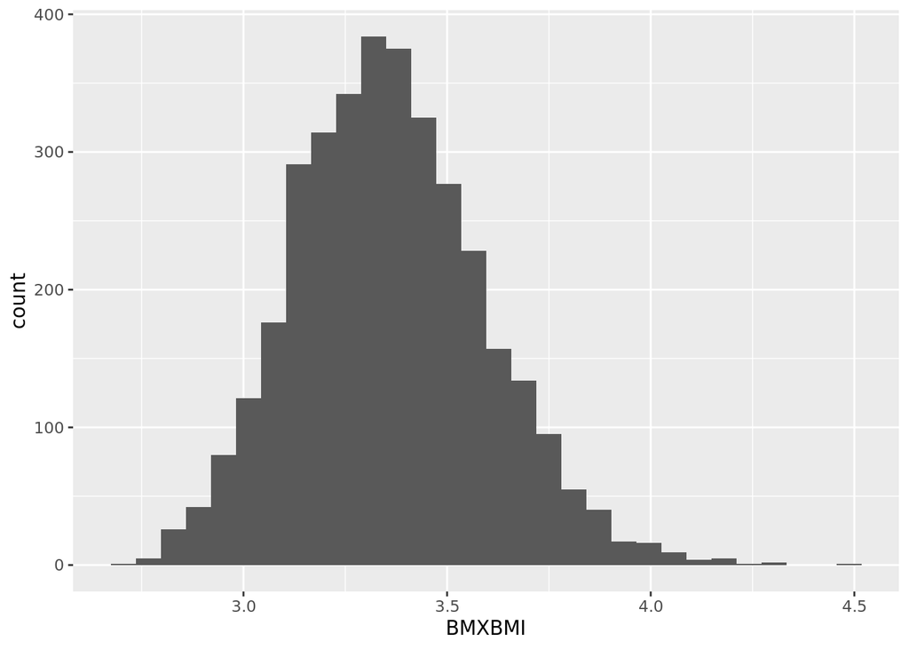

```r
 nhanes|> ggplot(aes(x = BMXBMI))+
   geom_histogram()
```

## Key Assumptions/Constraints

In order to use the gWQS package in an application setting, several conditions must be followed. The first condition is that the chemical exposures must ALL contribute in one direction. In order to contribute in one direction, all variables must be either positively correlated, or negatively correlated with each other. In addition to the correlation of the exposures, the dataset must be split into two sections. The first section is the training data for providing weights to the variables, while the second is used exclusively for verifying the model and ensuring that the results are reliable.

*In order to use weighted quantile sum regression with the `nhanes` data, it is important to first confirm that all constraints are satisfied:*

*An initial correlation model reveals that the URX predictor variables all contribute in a single direction, validating the appropriateness of the gWQS model.*

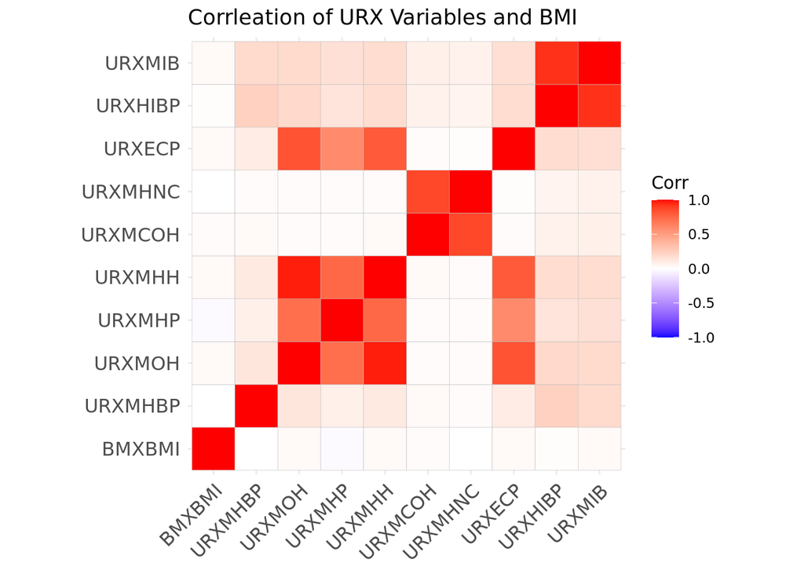

```r
cor_hanes <- cor(nhanes)

ggcorrplot(cor_hanes)+
  labs(title = "Corrleation of URX Variables and BMI")
```

```r
#Source http://www.sthda.com/english/wiki/ggcorrplot-visualization-of-a-correlation-matrix-using-ggplot2#:~:text=The%20easiest%20way%20to%20visualize,ggcorr()%20in%20ggally%20package
```

However, if we fit a normal linear regression model to these predictors, positive and negative estimates would be produced. Intuitively, the URX variables should all have positive coefficients, however, this model is not representative of this assumption. This is a demonstration of multi-collinearity, where there are there is a large uncertainty (variance) when calculating the coefficients. Therefore, the output of the model may produce unusual signs for the beta estimates.

As shown below, some of the URX betas are positive, while others are negative. Instead, we want to use a gWQS model which will provide a *unidirectional* output, similar to a standard linear regression model.

```r
#large uncertanty (variance) around the coefficients and multicolinearity (including that the coeffients may be negatve) - point estimate may be negative (abnormal signs)
linear_reg()|>
  fit(BMXBMI~., data = nhanes)|>
tidy()
```

```
## # A tibble: 10 × 5
##    term          estimate std.error statistic   p.value
##    <chr>            <dbl>     <dbl>     <dbl>     <dbl>
##  1 (Intercept)  3.36       0.00509   660.     0
##  2 URXMHBP     -0.0000177  0.000839   -0.0211 0.983
##  3 URXMOH       0.00209    0.00174     1.21   0.228
##  4 URXMHP      -0.00704    0.00164    -4.29   0.0000182
##  5 URXMHH       0.000405   0.00101     0.401  0.688
##  6 URXMCOH      0.00238    0.00105     2.26   0.0236
##  7 URXMHNC     -0.000869   0.000402   -2.16   0.0306
##  8 URXECP      -0.0000514  0.000285   -0.180  0.857
##  9 URXHIBP     -0.00567    0.00155    -3.67   0.000250
## 10 URXMIB       0.00185    0.000464    3.98   0.0000693
```

## WQS Model

Once the conditions are satisfied, a model can be produced, similarly to standard linear regression model. One difference from the linear model is that unique weights are assigned to the predictor variables.

$$g(\mu)= \beta_0 + \beta_0 \times (WQS)
+ \epsilon$$
or it can be written as an expanded model where $w_n$ corresponds the estimated weights for each X variable and $\theta_1$ is the predicted impact of the WQS method on all of the chemical exposures.

$$E[g(\mu)]= \theta_0 + \theta_1(w_1X_1 + w_2X_2 + ... w_nX_n)$$

Quantiles categorize each variable where qi = {0, 1, 2, 3, etc.}, which are given a corresponding weight. The weighted components are then summed and are fitted to the regression model. gWQS visualizes the assigned weights and regression fit as demonstrated in the package below:

## Model Fitting

The gWQS model model requires the explanatory mixtures to be saved to a variable. In this example, we saved them to `chem_names`.

Additionally, the output of the `gWQS` package is saved to the variable `results`.

*Key arguments in the qWQS package:*

`q` - specifies the number of quantiles to be used

`validation` - the percentage of the data set to be used for creating the weights/bootstrapping and the validating the model

`b1_pos` - specify `TRUE` if the data has a positive correlation and

`FALSE` if it has a negative correlation

`family` - type of association to be tested (ex: gaussian, binomial)

`data` - the data-frame containing the data to be tested

`b` - number of bootstrap samples

`mix_name` - a vector containing the names of the exposures

`seed` - set a seed which allows the results to be replicated

```r
chem_names <- names(nhanes)[2:10]

results <- gwqs(BMXBMI ~ wqs, mix_name = chem_names, data = nhanes,
                q = 10, validation = 0.6, b = 1, b1_pos = TRUE,
                b1_constr = FALSE, family = "gaussian", seed=1)
```

> It is important to set a seed in the gWQS model. This ensures that the results are replicated consistently when the model is rendered.

## Model Interpretation and Inference

The estimated weights are shown numerically below:

```r
head(results$final_weights)
```

```
##         mix_name  mean_weight
## URXECP    URXECP 4.635526e-01
## URXMCOH  URXMCOH 4.231238e-01
## URXMIB    URXMIB 1.133201e-01
## URXMHH    URXMHH 1.766439e-06
## URXMOH    URXMOH 1.535145e-06
## URXMHNC  URXMHNC 1.131088e-07
```

Using these weights, the final regression results can be obtained:

```r
summary(results)
```

```
##
## Call:
## gwqs(formula = BMXBMI ~ wqs, data = nhanes, mix_name = chem_names,
##     b = 1, b1_pos = TRUE, b1_constr = FALSE, q = 10, validation = 0.6,
##     family = "gaussian", seed = 1)
##
## Deviance Residuals:
##      Min        1Q    Median        3Q       Max
## -0.57623  -0.16121  -0.01061   0.14323   0.95830
##
## Coefficients:
##             Estimate Std. Error t value Pr(>|t|)
## (Intercept) 3.318215   0.009803 338.499  < 2e-16 ***
## wqs         0.014915   0.002861   5.214 2.03e-07 ***
## ---
## Signif. codes:  0 '***' 0.001 '**' 0.01 '*' 0.05 '.' 0.1 ' ' 1
##
## (Dispersion parameter for gaussian family taken to be 0.05406224)
##
##     Null deviance: 115.65  on 2113  degrees of freedom
## Residual deviance: 114.18  on 2112  degrees of freedom
## AIC: -164.58
##
## Number of Fisher Scoring iterations: 2
```

The Regression output:

$$\widehat{log(BMXBMI)} = 3.31 + 0.015
\times (WQS)$$

Interpretation for the model:

- *When quantiles of the URX variables are 0, the estimated log BMI is approximately 3.31.*
- *As every quantile of the WQS increases by 1, the log BMI increases on average by 0.015.*

It is important to acknowledge the uncertainty in the WQS output. One method of accounting for this uncertainty is through confidence intervals. A confidence interval allows us to understand between which values are the estimations from our model likely to occur in the real-world, accounting for model variations. Using the `confint(model name)` function in R, we can determine between which WQS coefficient by the model.

```r
confint(results)
```

```
##                   2.5 %     97.5 %
## (Intercept) 3.299001588 3.33742763
## wqs         0.009308286 0.02052193
```

We can be 95% confident that the true wqs coefficient falls within the interval 0.009 and 0.021.

The gWQS package provides methods for understanding and visualizing the results. One of the most helpful ways to view the output of is through visualizations of the weights assigned to each variable. The weights can demonstrate which exposures from the urine samples are impactful in predicting BMI and which are less helpful.

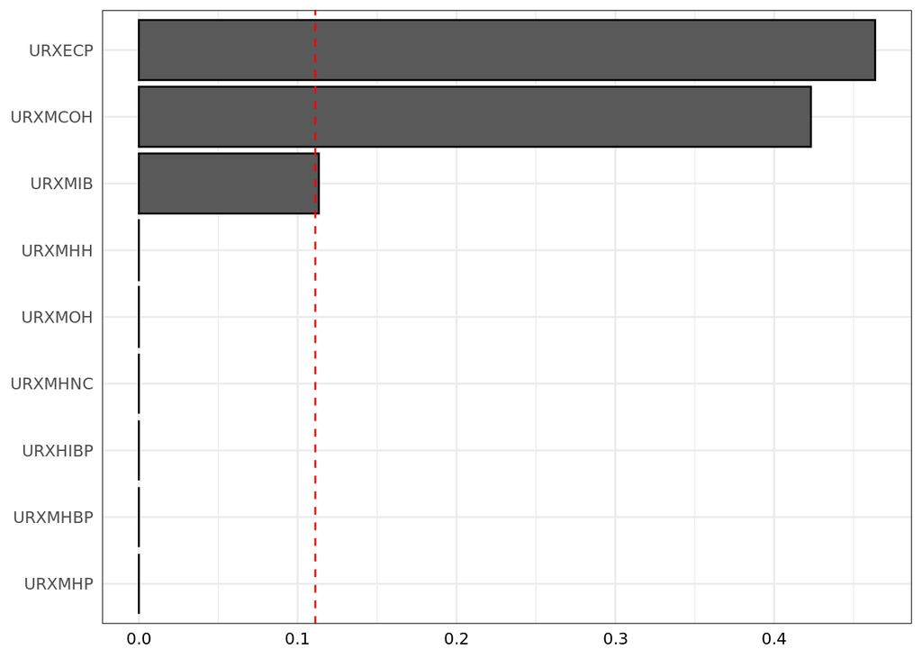

```r
gwqs_barplot(results)
```

In addition to the weights assigned to the chemical exposures, it can be helpful to visualize the overall relationship of the WQS model and the predicted BMI. To visualize this relationship, a scatterplot can be utilized to see if there is a linear relationship in the model.

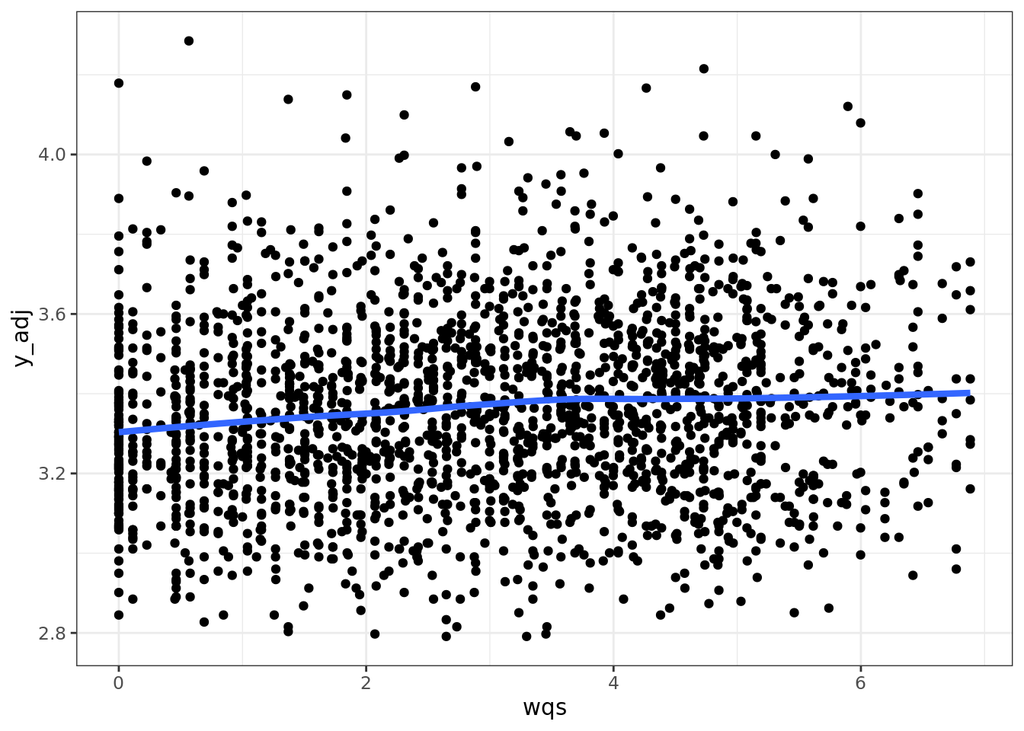

```r
gwqs_scatterplot(results)
```

The scatterplot of the WQS model and BMI demonstrate the linear relationship between the URX chemicals and log BMI.

## Model Dignostics

We check the assumption that all the chemical exposures contribute in the same direction using our expertise.

The other assumptions are similar to those of linear regressions. Therefore, we also examine the residuals. Residuals are the differences between the the actual data points in the NHANES dataset and the predicted values from our gWQS model. By examining the residuals on a graph, we can determine if there are any relationships, causing issues with the model.

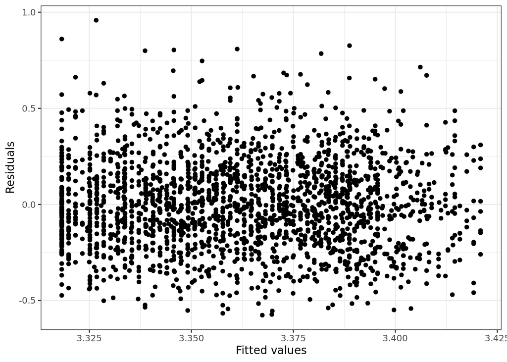

```r
gwqs_fitted_vs_resid(results)
```

The final visualization shows the residuals and fitted values. As seen above, the points are distributed around zero and do not have any distinct patterns. Additional interpretations of the output models can be found [HERE](https://chem-mix.netlify.app/slides/01-linear_regression#Model_Diagonostics_and_Evaluations).

## Model Comparison

```r
results$fit
```

```
##
## Call:  glm(formula = formula, family = family, data = dtf, weights = wghts)
##
## Coefficients:
## (Intercept)          wqs
##     3.31821      0.01492
##
## Degrees of Freedom: 2113 Total (i.e. Null);  2112 Residual
## Null Deviance:       115.6
## Residual Deviance: 114.2     AIC: -164.6
```

- AIC - This is a statistic to compare two models - the smaller the AIC, the better the model. In this example, the AIC is -164.58.
- Null deviance can show how well the model predicts the response, solely using the regression intercept.
- Contrary, residual deviance demonstrates how well the model predicts the response, using the explanatory variables. The smaller the residual deviance, the better the accuracy of the regression model.

## Miscellaneous

Additional outputs from the model which may be helpful for diagnostics:

`results$bres` - displays the p-values for each of the bootstrap samples

`results$q_i` - the “cutoff” values which are used to create the quantiles

An additional method used to study the effects of highly correlated exposures on an outcome is the qgcomp package. This method follows similar procedures and assumptions of gWQS; however, the computation can be more efficient and it can also work with non-linear data. Although the gWQS package is more widely used, the qgcomp package can provide a structured approach to using variables that do not follow a linear pattern. All other assumptions are similar to this tutorial and a link is included below for further exploration.

https://cran.r-project.org/web/packages/qgcomp/vignettes/qgcomp-vignette.html

## Conclusion

In conclusion, the gWQS weighted the explanatory variables successfully as our model is considered to be statistically significant. By using the gWQS model with data where explanatory variables are all highly correlated, specific variables can be weighted according to their influence to the response variable. In the NHANES data set, chemicals URXMCOH, URXMIB, URXECP were weighted the highest by the gWQS model. In future tutorials, we will uncover additional methods to test highly correlated data through Bayesian sum regression.

## References:

- [How to Interpret Null & Residual Deviance](https://www.statology.org/null-residual-deviance/#:~:text=The%20residual%20deviance%20tells%20us,value%20of%20the%20response%20variable.)
- https://cran.r-project.org/web/packages/gWQS/vignettes/gwqs-vignette.html
- http://cran.nexr.com/web/packages/gWQS/vignettes/gwqs-vignette.html
- http://cran.nexr.com/web/packages/gWQS/gWQS.pdf